# GEL - Allele age and ancestral diversity

Sam Tallman

24 September, 2026

# 1 Packages

```r
library(tidyverse)
library(data.table)
library(MASS)
library(magrittr)
library(viridis)
library(broom)
library(Rcpp)
library(cowplot)
library(ggpubr)
library(zoo)
library(reticulate)
library(polars)
library(tidypolars)
library(glue)
library(scales)
library(purrr)

## conda environment.
use_virtualenv("/opt/python_env", required = TRUE)
```

# 2 Parameters

```r
## Python functions for reticulate
source_python("functions/gel-funcs.py")

## Source R functions
source("functions/gel-funcs.R")
source("functions/gel-plotting_funcs.R")
```

File paths from config…

```r
config <- yaml::read_yaml("config/config.yaml")

# Fill templates
paths <- lapply(config$paths, function(path) {
  if (grepl("\\{chrom\\}|\\{chrom_no_prefix\\}", path)) {
    return(NULL)   # skip chrom-templated paths
  }
  glue(path,
       data_dir       = config$paths$data_dir,
       singletons_dir = config$paths$singletons_dir
  )
})

paths <- Filter(Negate(is.null), paths)
```

Paths and information from the dated trees

```r
## List of trees (with singletons included)
ts_tsv <- params$ts_tsv
trees_list <- read_tsv(ts_tsv)
ts_dir <- paths$ts_dir
ts_suffix <- ".trees.tsz"
```

# 3 Data

We read in the relevant data from chromosomes - Generated using gel_ts-df.Rmd

```r
# Extract relevant columns from the ts_df for all chromosomes
selected_columns <- c(
    "chromosome",
    "position",
    "ancestral_state",
    "derived_state",
    "ts_name",
    "AC_ts",
    "AF_ts",
    "cpg_transition",
    "shape_time",
    "scale_time",
    "AC_oce_ga100k_genomes",
    "AN_oce_ga100k_genomes",
    "upper_conf_time",
    "lower_conf_time",
    "sd_time",
    "cv_time",
    "in_gnomad",
    "mean_time",
    "mutation_root_parent",
    "pop",
    "singleton_sample_id"
  )
```

Lazy loading for filtering etc. We exclude: - Mutations below the unconstrained root - Mutations without any dates in the tree sequences See outputs of gel-summary_stats.Rmd for numbers of these specific mutations

```r
ts_lf_merge <- scan_parquet_polars(file.path(paths$output_dir, "all-chr*-df.parquet")) |>
  dplyr::select(all_of(selected_columns)) |>
  compute() |>
  filter(
    mutation_root_parent == FALSE & !is.na(mean_time)
  )
```

# 4 Analysis

## 4.1 PCA groupings

PCA groupings were generated previously using the assign_gnomad_pop_hail.py - Using the gnomADv4.1 publicly available PCA loadings + random forest from: https://gnomad.broadinstitute.org/data#v4

```r
pops_df <- read_tsv(paths$pops_path)
## Put "oth" + "fin" into remaining
remain_collapse <- c("fin", "oth")
pops_no_remaining <- pops_df |>
filter(
  !pop %in% remain_collapse
)

pops_df <- pops_df |>
  mutate(pop = ifelse(pop %in% remain_collapse, "remaining", pop))

### Consistent colouring...
pop_colours_vec <- c(
  "#CC79A7", "#F0E442", "#0072B2", "#D55E00", "grey80", "#009E73", "#E69F00", "#56B4E9"
)
```

Tally numbers of individuals per PCA group

```r
group_numbers <-
  pops_df |>
  count(pop) |>
  arrange(n) |>
  mutate(
    pop = factor(pop, levels = pop),
    Dataset = "GEL"
  ) |>
  mutate(prop = n / sum(n))

knitr::kable(group_numbers, bookends = FALSE)
```

| pop | n | Dataset | prop |
| --- | --- | --- | --- |
| mid | 71 | GEL | 0.0014936 |
| amr | 142 | GEL | 0.0029873 |
| asj | 305 | GEL | 0.0064163 |
| eas | 335 | GEL | 0.0070474 |
| remaining | 1212 | GEL | 0.0254970 |
| afr | 1827 | GEL | 0.0384348 |
| sas | 3837 | GEL | 0.0807195 |
| nfe | 39806 | GEL | 0.8374040 |

As expected given this UK-based cohort the number of individuals labelled as “nfe” i.e. Non-Finnish European is highly over-represented.

Plot group numbers as bar plot

```r
plot_4a_legend <- group_numbers |>
pop_strat_bar_plot(
  legend_text_size = 20,
  legend_title_size = 20
) +
labs(
  x = "",
  y = "Number of individuals (thousands)"
) +
scale_colour_manual(
  values = pop_colours_vec
) +
scale_fill_manual(
  values = pop_colours_vec
) +
theme(
  legend.position = "top"
)

## Legend for the entire figure
plot_4_legend <- as_ggplot(
  get_legend(plot_4a_legend)
)

## Only bar
plot_4a <- plot_4a_legend +
theme(
  legend.position = "none"
)
```

## 4.2 Ind vs all pairwise coalescence

How does the over-representation of European ancestry individuals impact coalescences within the trees?

We’ll restrict to unrelated individuals to avoid inflation…

```r
## Unrelated pops
unrel_pops <- pops_df |>
unrelated_filter(
  sample_col = "sgkit_sample_id",
  aggV2_kinship_matrix = paths$aggV2_kinship_matrix,
  kinship_coefficient = 0.0442
)
```

```
## Number of relatives removed: 4849
```

Get ~500 inidividuals from each pop. - Or less if pop n < 500

```r
num_samples <- 500 # Maximise as 500 samples...
coal_sample_ids <- paste0(paths$output_dir, "checkpoints/coal_sample.ids")
if (!file.exists(coal_sample_ids)) {
  sampled_ids <- unrel_pops %>%
    filter(pop != "fin") %>%
    group_by(pop) %>%
    group_modify(~ sample_n(.x, size = min(nrow(.x), num_samples))) %>%  # Allow variable n
    ungroup() %>%
    pull(sgkit_sample_id)
  write_tsv(
    as.data.frame(sampled_ids), coal_sample_ids
  )
} else {
  sampled_ids <- read_tsv(coal_sample_ids) %>%
    pull(sampled_ids)
}
```

We’ll restrict to the largest chromosome chunk…

```r
ts_path = paste0(ts_dir, "all-chr17q45M~83M-filterNton23SiteDensity-truncate-0-0-0-mm0-post-processed-simplified-SDN-singletons-dated", ts_suffix)
```

```r
pair_coal_one <- function(
  sample_id,
  ts_path,
  out_dir = paste0(paths$data_dir, "pair_coal_counts/chr17q45M~83M/"),
  time_min = 1e1,
  time_max = 2e5,
  bin_width = 10,
  overwrite = FALSE
) {
  dir.create(out_dir, recursive = TRUE, showWarnings = FALSE)
  outfile <- file.path(out_dir, sprintf("%s_pair_coal_counts.tsv", sample_id))

  # If checkpoint exists and not overwriting, return it
  if (file.exists(outfile) && !overwrite) {
    message("✓ Exists: — reading cached file.")
    return(
      readr::read_tsv(outfile, show_col_types = FALSE) |>
      mutate(sgkit_sample_id = sample_id)
    )
  }

  # Call the Python function
  df_py <- indiv_vs_all_pair_coal_counts(
    ts_path = ts_path,
    focal_sample_id = sample_id,
    time_min = time_min,
    time_max = time_max,
    bin_width = bin_width
  )

  df <- reticulate::py_to_r(df_py) |>
    mutate(sgkit_sample_id = sample_id)

  message("  → Wrote")
  readr::write_tsv(df, outfile)
  df
}

pair_coal_many <- function(
  sample_ids,
  ts_path,
  out_dir = paste0(paths$data_dir, "pair_coal_counts/chr17q45M~83M/"),
  time_min = 1e1,
  time_max = 2e5,
  bin_width = 10,
  overwrite = FALSE,
  progress = TRUE
) {
  sample_ids <- unique(stats::na.omit(sample_ids))
  res <- lapply(sample_ids, function(sid) {
    if (progress) message("⇢ ", sid)
    pair_coal_one(
      sample_id = sid,
      ts_path = ts_path,
      out_dir = out_dir,
      time_min = time_min,
      time_max = time_max,
      bin_width = bin_width,
      overwrite = overwrite
    )
  })
  dplyr::bind_rows(res)
}
```

Wrangling of the data - This could have been done easier, but I wrote very granular time windows for flexibility…

```r
coal_inds_wrangled_df <- paste0(paths$output_dir, "checkpoints/coal_counts_plot.csv")
if (file.exists(coal_inds_wrangled_df)) {
  coal_inds <- read_csv(coal_inds_wrangled_df)
} else {
  pair_coal_all <-
    pair_coal_many(
       sampled_ids,
       ts_path = ts_path
    )
  num_bins <- 50  # Adjust as needed
  window_bounds <- 10^seq(
    log10(min(coals$time_windows, na.rm = TRUE)),
    log10(max(coals$time_windows[is.finite(coals$time_windows)], na.rm = TRUE)),
    length.out = num_bins + 1
  )
  coal_inds <- pair_coal_all %>%
    left_join(unrel_pops, by = "sgkit_sample_id") %>%
    mutate(pop = ifelse(pop == "oth", "remaining", pop)) %>%
    mutate(pop = factor(pop, levels = group_numbers$pop)) %>%
    mutate(window = cut(time_windows, breaks = window_bounds, include.lowest = TRUE)) %>%
    group_by(window, individual_id) %>%
    summarise(
      pop = first(pop),  # Preserve population info
      rolling_avg = mean(pair_coal_counts, na.rm = TRUE),
      start_time = min(time_windows, na.rm = TRUE),
      end_time = max(time_windows, na.rm = TRUE),
      .groups = "drop"
    )
  write_csv(coal_inds, coal_inds_wrangled_df)
}
```

Get pop average coalescence counts…

```r
coals_pops <- coal_inds %>%
  group_by(pop, window) %>%
  reframe(pop_avg = mean(rolling_avg, na.rm = TRUE), .groups = "drop", start_time = start_time)
```

Generate the plot…

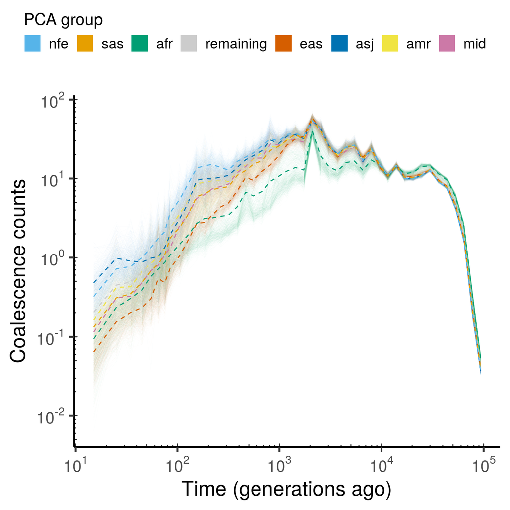

```r
# lazy, add the same figure legend..
supp_legend <-
get_legend(group_numbers |>
  pop_strat_bar_plot(
    base_size = 15
  ) +
  scale_colour_manual( values = pop_colours_vec) +
  scale_fill_manual(values = pop_colours_vec)
)
coal_ind_vs_all_pops <- plot_coalescence(
  coal_inds, coals_pops,
  order_vec = group_numbers$pop,
  facet = FALSE, pop_colours_vec = pop_colours_vec
)
plot_show_coal <-
  ggarrange(
    supp_legend,
    NULL,
    coal_ind_vs_all_pops,
    ncol = 1, heights = c(0.15, 0.05, 1)
  )
plot_show_coal
```

Write to plot data…

```r
ggsave(paste0(paths$plots_dir, "ind_vs_all_pop_pair_coal_counts.pdf"), plot_show_coal, height = 7, width = 7)
```

## 4.3 Alleles and ages by PCA group

Defined ultra-rare variants AC count in GEL - Define as less than 1 in 1000 haplotypes

```r
ur_ac_count <- max_ac_count(ts_lf_merge, AF_thresh = 0.001)
ur_ac_count
```

```
## [1] 95
```

```r
pop_order_w_nonspecific <- c(as.character(group_numbers$pop), "nonspecific")
```

Look at how many variants are specific to given pop at a given AC bin - Up to ultra-rare 0.1% threshold

```r
df_counts <- ts_lf_merge %>%
  group_by(pop, AC_ts) %>%
  summarise(
    n = n(),
    gmean_age = exp(mean(log(mean_time)))
  ) |>
  as_tibble() |>
  ungroup()

comp_trunc_ur <-  df_counts %>%
  filter(AC_ts < ur_ac_count) %>%
  mutate(
    log_gm    = log(gmean_age)
  ) %>%
  group_by(AC_ts, pop) %>%
  summarise(
    log_gm = weighted.mean(log_gm, w = n, na.rm = TRUE),  # uses original n vector
    n      = sum(n),
    .groups = "drop"
  ) %>%
  mutate(
    gmean_age = exp(log_gm)
  ) %>%
  group_by(AC_ts) %>%
  mutate(prop = n / sum(n)) %>%
  ungroup() |>
  mutate(
    pop = factor(pop, levels = pop_order_w_nonspecific)
  )
```

Plot this

```r
pca_counts_by_ac <- ggplot(comp_trunc_ur, aes(x = AC_ts, y = prop, fill = pop, colour = pop)) +
  geom_col(position = "stack", width = 1) +
  scale_y_continuous(labels = label_percent(), expand = c(0, 0)) +
  scale_x_continuous(expand = c(0, 0)) +
  labs(x = "", y = "% of variants at AC", fill = "PCA group") +
  theme_bw(base_size = 20) +
  theme(
    axis.text.x = element_text(size = 1, colour = "white"),
    axis.ticks.x = element_blank(),
    legend.position = "top",
    panel.grid = element_blank()
  ) +
  scale_fill_manual(
    values = c(pop_colours_vec, "grey50")
  ) +
  scale_colour_manual(
    values = c(pop_colours_vec, "grey50"), guide = "none"
  )
```

Vast majority of variants of higher AC counts are non-specific

```r
# Total mutations in the full dataset
total_mutations <- ts_lf_merge %>%
  summarise(
    total_mutations = n()
  )

# Total mutations per PCA group in the full dataset
mutations_by_pop <- ts_lf_merge %>%
  count(
    pop,
    name = "n_mutations"
  ) %>%
  arrange(desc(n_mutations))


# Total number of mutations represented in the figure
total_mutations_in_figure <- comp_trunc_ur %>%
  summarise(
    total_mutations = sum(n)
  )

mutations_by_pop_in_figure <- comp_trunc_ur%>%
  group_by(pop) %>%
  summarise(
    n_mutations = sum(n)
  )

knitr::kable(
  total_mutations,
  caption = "Total number of mutations"
)
```

Total number of mutations

| total_mutations |
| --- |
| 23079190 |

```r
knitr::kable(
  mutations_by_pop,
  caption = "Total number of mutations by PCA group"
)
```

Total number of mutations by PCA group

| pop | n_mutations |
| --- | --- |
| nfe | 12184807 |
| nonspecific | 5159652 |
| sas | 2630374 |
| afr | 1732344 |
| remaining | 720200 |
| eas | 435288 |
| amr | 110913 |
| mid | 54416 |
| asj | 51196 |

```r
knitr::kable(
  total_mutations_in_figure,
  caption = "Total number of mutations included in the geometric mean age figure"
)
```

Total number of mutations included in the geometric mean age figure

| total_mutations |
| --- |
| 21882336 |

```r
knitr::kable(
  mutations_by_pop_in_figure,
  caption = "Number of mutations included in the geometric mean age figure by PCA group"
)
```

Number of mutations included in the geometric mean age figure by PCA group

| pop | n_mutations |
| --- | --- |
| mid | 54416 |
| amr | 110913 |
| asj | 51196 |
| eas | 435288 |
| remaining | 720200 |
| afr | 1732343 |
| sas | 2630369 |
| nfe | 12181288 |
| nonspecific | 3966323 |

By population and AC

Summarise geometric mean age distributions…

```r
comp_trunc_ur %<>%
 filter(n > 15) # remove intervals with < 15 mutations

pca_age_by_ac <- ggplot(comp_trunc_ur, aes(x = AC_ts, y = gmean_age, colour = pop, fill = pop, group = pop)) +
  geom_point(shape = 21) +
  geom_smooth() +
  theme_classic(base_size = 20) +
  theme(
    legend.position = "NONE",
    axis.ticks.x = element_blank()
  ) +
  scale_y_log10(
      expand = c(0,0),
      breaks = scales::trans_breaks("log10", function(z) 10^z),
      labels = scales::trans_format("log10", scales::math_format(10^.x))
    ) +
  scale_x_continuous(expand = c(0,0)) +
  annotation_logticks(sides = "l", linewidth = 0.5, colour = "grey20") +
  scale_fill_manual(
    values = c(pop_colours_vec, "grey50")
  ) +
  scale_colour_manual(
    values = c(pop_colours_vec, "grey50")
  ) +
  labs(x = "Derived allele count (DAC)", y = "Geometric mean allele age\ngenerations ago")
```

Combine the two plots for a Supplementary figure

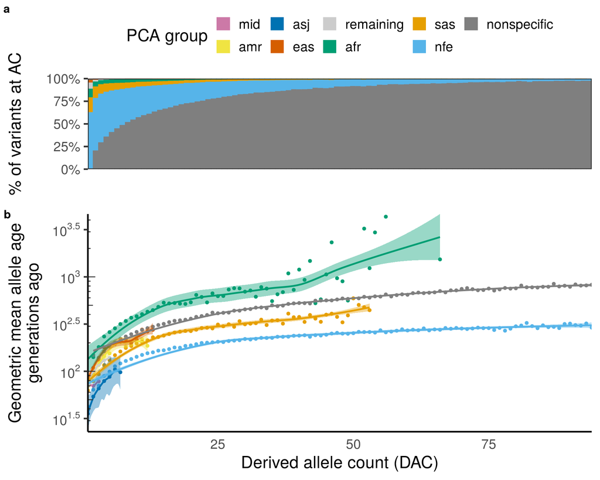

```r
comb_age_by_ac_pca <- plot_grid(
  pca_counts_by_ac,
  pca_age_by_ac,
  rel_heights = c(0.75, 1),
  labels = c("a", "b"),
  ncol = 1, align = "v"
)
comb_age_by_ac_pca
```

Write to plot data…

```r
ggsave(paste0(paths$plots_dir, "pops_geomean_age_by_ac.pdf"), comb_age_by_ac_pca , height = 8, width = 9)
```

## 4.4 Singletons by PCA group

Use the pops_df and kinship matrix (from aggV2) to make sure we can get an unrelated inds. subset.

Create a “singletons only” lazyframe with those among unrelated individuals excluded…

```r
## Exclude singeltons in individuals with close familial relatives in the data
ts_df_sing <- ts_lf_merge %>%
filter(
  AC_ts == 1 &
  singleton_sample_id %in% unrel_pops$sgkit_sample_id
)
```

Singletons by pop age summary

```r
age_by_pca_sing <- ts_df_sing |>
  group_by(pop) |>
  summarise(
    gmean_age = exp(mean(log(mean_time))),
    mean_age  = mean(mean_time)
  )
knitr::kable(age_by_pca_sing)
```

| pop | gmean_age | mean_age |
| --- | --- | --- |
| nfe | 42.80872 | 67.82214 |
| sas | 63.17754 | 105.50470 |
| asj | 35.81422 | 60.90462 |
| amr | 73.18137 | 119.80205 |
| remaining | 69.54521 | 190.59100 |
| afr | 84.47557 | 280.75844 |
| mid | 74.02817 | 147.11819 |
| eas | 84.13676 | 216.56630 |

NFE vs everyone else

```r
age_by_nfe_vs_all_sing <- ts_df_sing |>
  mutate(
    pop_nfe = ifelse(pop == "nfe", pop, "other participants")
  ) |>
  group_by(pop_nfe) |>
  summarise(
    gmean_age = exp(mean(log(mean_time))),
    mean_age  = mean(mean_time)
  )
knitr::kable(age_by_nfe_vs_all_sing)
```

| pop_nfe | gmean_age | mean_age |
| --- | --- | --- |
| other participants | 71.19221 | 176.18609 |
| nfe | 42.80872 | 67.82214 |

eCDF for singletons stratified by predicted ancestry group

```r
plot_4b <- ts_df_sing |>
  dplyr::select(
    pop, mean_time
  ) |>
  as_tibble() |>
  ecdf_grouped_plot(
    group_col = "pop",
    group_vals = as.character(group_numbers$pop),
    discrete = TRUE
  ) +
  labs(
    x = "Singleton age (generations)",
    y = "eCDF"
  ) +
  theme(legend.position = "NONE") +
  scale_colour_manual(values = pop_colours_vec)
```

```
## # A tibble: 8 × 2
##   pop       geomean_allele_age
##   <fct>                  <dbl>
## 1 afr                     84.5
## 2 amr                     73.2
## 3 asj                     35.8
## 4 eas                     84.1
## 5 mid                     74.0
## 6 nfe                     42.8
## 7 remaining               69.5
## 8 sas                     63.2
```

Looking at the distributions of singleton ages vs appearance in gnomAD by PCA group

```r
num_quantiles <- 150 # go across 150 quantiles
fig4c_plot_data <- ts_df_sing |>
  filter(AC_ts == 1) |>
  dplyr::select(pop, in_gnomad, mean_time) |>
  as_tibble() |>
  mutate(quantile = ntile(log10(mean_time), num_quantiles)) |>
  mutate(pop = factor(pop, levels = c(as.character(group_numbers$pop), "nonspecific"))) |>
  group_by(pop, in_gnomad, quantile) |>
  summarise(mean_age = log10(median(mean_time, na.rm = TRUE)),
            n = n()
  ) |>
  group_by(pop, quantile) |>
  mutate(prop = n / sum(n)) |>
  filter(in_gnomad)
```

Plot

```r
plot_4c <- fig4c_plot_data |>
  ggplot(aes(x = mean_age, y = prop*100, colour = pop, fill = pop, group = pop)) +
  geom_smooth(linewidth = 0.5, method = "lm", se = FALSE) +
  geom_point(size = 0.5) +
  theme_classic(base_size = 20) +
  theme(
    legend.position = "NONE"
  ) +
  scale_color_manual(values = c(pop_colours_vec, "black")) +
  scale_fill_manual(values = c(pop_colours_vec, "black")) +
  coord_cartesian(ylim = c(20, 100), xlim = c(0, 4)) +
  labs(
    y = "Observed in gnomADv4.1 (%)",
    x = "Singleton age (generations)"
  ) +
  annotation_logticks(
    linewidth = 0.5,
    colour = "grey20",
    short = unit(0.05, "cm"),
    mid = unit(0.075, "cm"),
    long = unit(0.1, "cm"),
    sides = "b"
  ) +
  scale_x_continuous(
    labels = scales::math_format(10^.x)
  )
```

## 4.5 Number vs age of singletons

Number of singletons could be a good proxy for relative relatedness to rest of dataset That is, if you have more singletons, it’s likely that you have fewer close relatives with other people in the dataset. As such, singletons should be on longer branches, and appear older on average than those who have closer genetic ancestors in the dataset

We can thus perform a continuous evaluation vs just looking at the discrete PCA groupings

For example, looking at: - Number of singletons vs geometric mean age of the singletons per unrelated individual.

```r
# Process the data for central plot
anc_agesd_plot_data <- ts_df_sing |>
  group_by(singleton_sample_id, pop) |>
  summarise(
    number_of_singletons = n(),
    geometric_mean_age_singletons = exp(mean(log(mean_time))),
  ) |>
  distinct() |>
  as_tibble() |>
  mutate(pop = factor(pop, levels = group_numbers$pop)) |>
  arrange(desc(number_of_singletons))
```

Plot this relationship

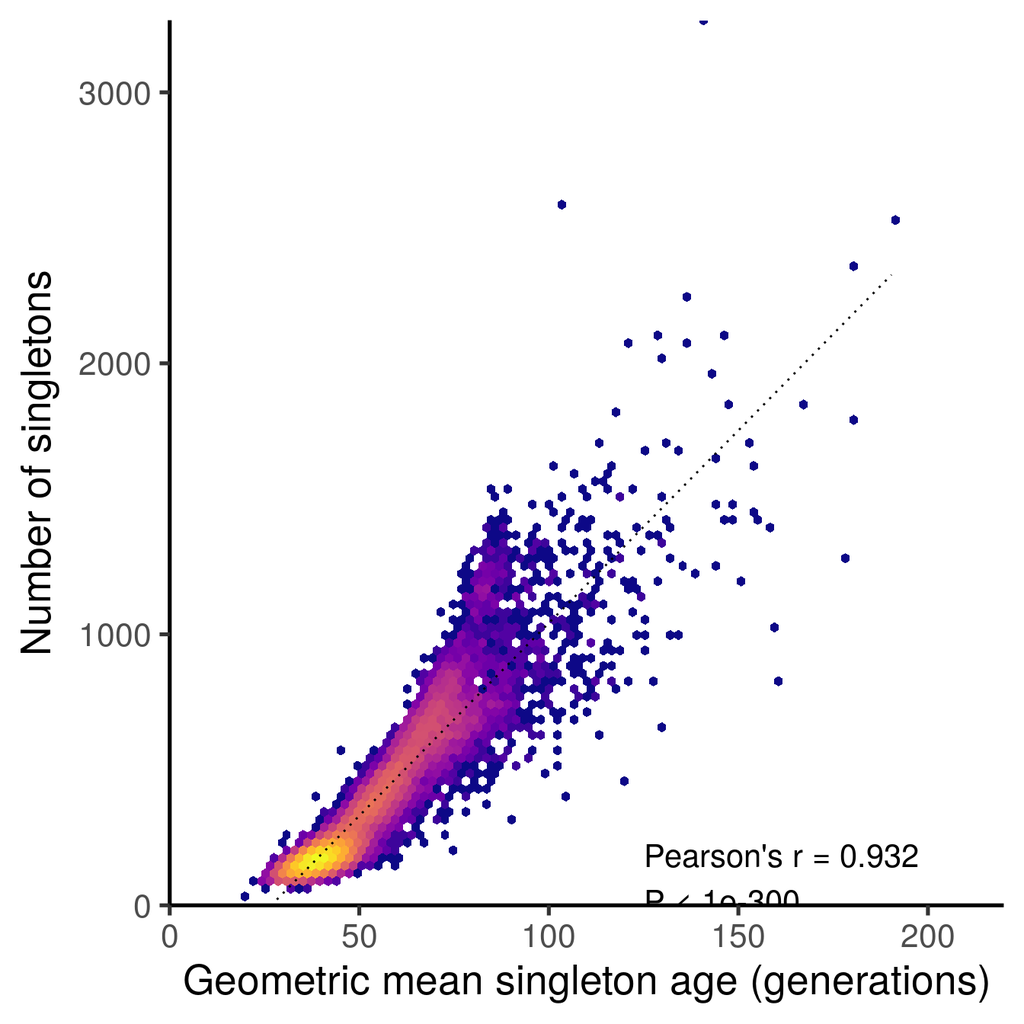

```r
corr_plot <- create_joint_density_plot(
  to_plot = anc_agesd_plot_data,
  group_numbers = group_numbers,
  smooth_linewidth = 0.5,
  include_group_hists = FALSE,
  cor_size = 5.5,
  cor_method = "pearson",
  cor_label_x = 125,
  cor_label_y = 100,
  pop_colours_vec = pop_colours_vec
)
corr_plot
```

Test the spearman’s correlation

```r
test = cor.test(anc_agesd_plot_data$geometric_mean_age_singletons, anc_agesd_plot_data$number_of_singletons, method = "spearman", use = "complete.obs")
test$p.value
```

```
## [1] 0
```

Test the pearsons’s correlation

```r
test_pearson = cor.test(anc_agesd_plot_data$geometric_mean_age_singletons, anc_agesd_plot_data$number_of_singletons, use = "complete.obs")
test$p.value
```

```
## [1] 0
```

Does this correlation hold within PCA groupings as well - e.g. continuous relationship within the groups, not just the whole dataset?

```r
correlation_results <- anc_agesd_plot_data |>
  group_by(pop) |>
  group_modify(~{

    cor_data <- .x |>
      filter(
        complete.cases(
          geometric_mean_age_singletons,
          number_of_singletons
        )
      )

    test <- cor.test(
      cor_data$geometric_mean_age_singletons,
      cor_data$number_of_singletons,
      method = "spearman"
    )

    tibble(
      n_samples = nrow(cor_data),
      n_singletons = sum(cor_data$number_of_singletons),
      spearman_r = unname(test$estimate),
      p_value = test$p.value
    )

  }) |>
  ungroup()

knitr::kable(correlation_results)
```

| pop | n_samples | n_singletons | spearman_r | p_value |
| --- | --- | --- | --- | --- |
| mid | 67 | 50285 | 0.8126116 | 0 |
| amr | 132 | 100030 | 0.9237984 | 0 |
| asj | 273 | 39353 | 0.4972705 | 0 |
| eas | 312 | 350720 | 0.4017322 | 0 |
| remaining | 956 | 544603 | 0.8956243 | 0 |
| afr | 1451 | 1068335 | 0.8090099 | 0 |
| sas | 3433 | 1727286 | 0.9159637 | 0 |
| nfe | 36062 | 7094847 | 0.6976790 | 0 |

Stratify by PCA group

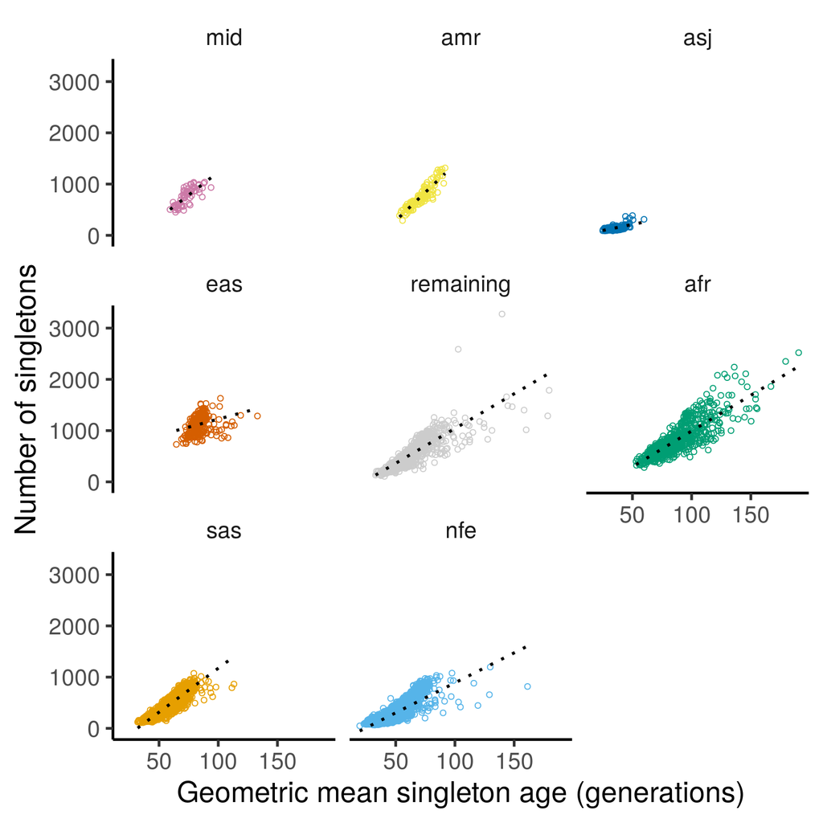

```r
plot_supp_pca_strat <- anc_agesd_plot_data %>%
  ggplot(aes(
    x = geometric_mean_age_singletons, y = number_of_singletons, colour = pop
  )) +
  theme_classic(base_size = 20) +
  geom_point(shape = 21) +
  geom_smooth(method = "lm", linetype = "dotted", se = FALSE, colour = "black") +
  theme(
    legend.position = "none",
    strip.background = element_blank()
  ) +
  facet_wrap(~pop) +
  labs(
    x = "Geometric mean singleton age (generations)",
    y = "Number of singletons"
  ) +
  scale_colour_manual(values = pop_colours_vec)
plot_supp_pca_strat
```

Write to plot data…

```r
ggsave(paste0(paths$plots_dir, "popstrat_nsingletons_vs_geomean_age.pdf"), plot_supp_pca_strat, height = 8, width = 8)
```

Are there participants that seem like strong outliers (median absolute deivation > 4, for example)?

```r
df_mad <- anc_agesd_plot_data %>%
  group_by(pop) %>%
  mutate(
    # robust location & scale (per group)
    median_singletons = median(number_of_singletons, na.rm = TRUE),
    mad_singletons    = mad(number_of_singletons, center = median_singletons,
                            constant = 1.4826, na.rm = TRUE),

    median_age = median(geometric_mean_age_singletons, na.rm = TRUE),
    mad_age    = mad(geometric_mean_age_singletons, center = median_age,
                     constant = 1.4826, na.rm = TRUE),

    # MAD z-scores (how many MADs from the group median)
    zmad_singletons = ifelse(mad_singletons > 0,
                             (number_of_singletons - median_singletons) / mad_singletons, NA_real_),
    zmad_age        = ifelse(mad_age > 0,
                             (geometric_mean_age_singletons - median_age) / mad_age, NA_real_),

    # One-sided “excess” (above the median by > 4 MADs)
    extreme_excess_singletons = zmad_singletons > 4,
    extreme_excess_age        = zmad_age > 4

    # If you want two-sided outliers instead, use: abs(zmad_*) > 4
  ) %>%
  ungroup()

# Filter individuals that exceed both strict criteria
df_outliers <- df_mad |>
  filter(extreme_excess_age)
```

Summarise numbers of outliers

```r
# Print counts per population
df_outliers_summary <- df_outliers |>
  count(pop) |>
  rename(pop_outlier_n = n)

outliers_summary_table <- unrel_pops |>
  group_by(pop) |> tally() |>
  left_join(df_outliers_summary) |>
  mutate(prop = pop_outlier_n / n)
knitr::kable(outliers_summary_table)
```

| pop | n | pop_outlier_n | prop |
| --- | --- | --- | --- |
| afr | 1451 | 56 | 0.0385941 |
| amr | 132 | NA | NA |
| asj | 273 | 1 | 0.0036630 |
| eas | 312 | 15 | 0.0480769 |
| mid | 67 | NA | NA |
| nfe | 36062 | 1021 | 0.0283124 |
| remaining | 956 | 13 | 0.0135983 |
| sas | 3433 | 2 | 0.0005826 |

Let’s take the top 3 from each pop (or max top if < 3 outliers) for more exploration. - We will generate psuedo IDs to avoid printing and pulling based on actual GEL platekeys

```r
top3_by_pop <- df_outliers %>%
  dplyr::select(singleton_sample_id, pop, zmad_age, number_of_singletons, geometric_mean_age_singletons) %>%
  filter(!is.na(zmad_age)) %>%
  group_by(pop) %>%
  slice_max(order_by = zmad_age, n = 3, with_ties = FALSE) %>%  # top 3 per pop
  arrange(desc(zmad_age), .by_group = TRUE) %>%
  mutate(
    pop_rank  = row_number(),
    pseudo_id = sprintf("%s%02d", pop, pop_rank)  # e.g. NFE-01, NFE-02, …
  ) %>%
  ungroup()
```

## 4.6 Age vs frequency along individual haplotypes

Z standardise across frequency

```r
ts_lf_merge %<>%
z_normalise(
      group_col = "AC_ts",
      score_col = "mean_time",
      z_col = "time_z",
      log10 = TRUE
    )
```

Z-score along sample haplotypes

We will use our largest and most complete chromosome (chromosome 17) for this!

```r
# 0) Make sure checkpoint dir exists
chk_dir <- file.path(paths$output_dir, "checkpoints")
dir.create(chk_dir, recursive = TRUE, showWarnings = FALSE)

# 1) Precompute chr17 inputs once
chr <- "chr17"
base_df      <- ts_lf_merge %>% filter(chromosome == chr)
base_ts_list <- trees_list   %>% filter(chromosome == chr)
```

```r
# 2) Worker for one sample
process_one_z_haps <- function(id_from_table, pseudo_id) {
  z_out <- file.path(chk_dir, sprintf("%s-z_score-%s.tsv.gz", chr, pseudo_id))
  if (file.exists(z_out)) {
    message("✓ Exists: ", basename(z_out), " — reading cached file.")
    dt <- data.table::fread(z_out)
  } else {
    message("… Computing: ", pseudo_id)
    dt <- base_df %>%
      z_along_haps(
        ts_list       = base_ts_list,
        ts_dir        = ts_dir,
        individual_id = id_from_table
      )
    data.table::fwrite(dt, z_out, sep = "\t")
    message("  → Wrote: ", basename(z_out))
  }
  # simple, safe column add:
  dt$pseudo_id <- pseudo_id
  dt$singleton_sample_id <- id_from_table
  dt
}

# 3) Run for all top3 per pop
res_list <- map2(top3_by_pop$singleton_sample_id, top3_by_pop$pseudo_id, process_one_z_haps)
example_z_haps_all <- data.table::rbindlist(res_list, use.names = TRUE, fill = TRUE)
```

GNN along sample haplotypes - We need starts + ends of each contig to ensure we separate at the borders

```r
## ts_start_ends
ts_start_ends <- ts_lf_merge |>
  group_by(ts_name) |>
  summarise(start = min(position), end = max(position)) |>
  as_tibble()

base_ts_ranges <- ts_start_ends %>% dplyr::filter(grepl(chr, ts_name))
```

```r
# 2) Worker for one sample
process_one_gnn <- function(id_from_table, pseudo_id) {
  gnn_out <- file.path(chk_dir, sprintf("%s-gnn-%s.tsv.gz", chr, pseudo_id))

  if (file.exists(gnn_out)) {
    message("✓ Exists: ", basename(gnn_out), " — reading cached file.")
    dt <- data.table::fread(gnn_out)
  } else {
    message("… Computing GNN for ", pseudo_id)
    dt <- gnn_along_haps(
      ts_list        = base_ts_list,
      ts_dir         = ts_dir,
      ts_suffix      = ts_suffix,
      pops_df        = pops_no_remaining,
      starts_ends_df = base_ts_ranges,
      individual_id  = id_from_table
    )
    data.table::fwrite(dt, gnn_out, sep = "\t")
  }

  # simple, safe column add:
  dt$pseudo_id <- pseudo_id
  dt$singleton_sample_id <- id_from_table
  dt
}

# 3) Run for all rows in top3_by_pop
gnn_list <- purrr::map2(
  .x = top3_by_pop$singleton_sample_id,
  .y = top3_by_pop$pseudo_id,
  ~process_one_gnn(id_from_table = .x, pseudo_id = .y)
)

# Optional: combine
example_gnn_haps_all <- data.table::rbindlist(gnn_list, use.names = TRUE, fill = TRUE)
```

Plot frequency controlled age zscore per haplotype among outliers

```r
hap1_z_plot_list <- list()
hap2_z_plot_list <- list()
for (psuedo in top3_by_pop$pseudo_id) {
  ## First haplotype
  hap1_z_plot_list[[psuedo]] <-
    example_z_haps_all |>
      filter(pseudo_id == psuedo) |>
      mutate(time_z = ifelse(time_z > 5, 5, time_z)) |>
      adac_along_haps_plot(
        adac_col = "time_z",
        AC_thresh = ur_ac_count,
        AC_highlight = c(1:ur_ac_count),
        haplotype_number = "Haplotype 1",
        remove_x_axis = TRUE,
        rolling_average_nmutations = 10
      ) +
      coord_cartesian(
        ylim = c(-5, 5),
        xlim = c(min(example_gnn_haps_all$start)/1000000, max(example_gnn_haps_all$end)/1000000)
      ) +
      scale_y_continuous(breaks = c(-4, 0, 4))
  ## Second haplotype
  hap2_z_plot_list[[psuedo]] <-
    example_z_haps_all |>
      filter(pseudo_id == psuedo) |>
      mutate(time_z = ifelse(time_z > 5, 5, time_z)) |>
      adac_along_haps_plot(
        adac_col = "time_z",
        AC_thresh = ur_ac_count,
        AC_highlight = c(1:ur_ac_count),
        haplotype_number = "Haplotype 2",
        remove_x_axis = TRUE,
        rolling_average_nmutations = 10
      ) +
      coord_cartesian(
        ylim = c(-5, 5),
        xlim = c(min(example_gnn_haps_all$start)/1000000, max(example_gnn_haps_all$end)/1000000)
      ) +
      scale_y_continuous(breaks = c(-4, 0, 4))
}
```

Same for GNN

```r
hap1_gnn_plot_list <- list()
hap2_gnn_plot_list <- list()
for (psuedo in top3_by_pop$pseudo_id) {
  hap1_gnn_plot_list[[psuedo]] <- example_gnn_haps_all |>
    filter(pseudo_id == psuedo) |>
    gnn_along_haps_plot(
      pop_vec = group_numbers$pop[!group_numbers$pop == "remaining"],
      haplotype_number = 2, # reversed due to mistake
      remove_x_axis = TRUE
    ) +
    scale_colour_manual(values = pop_colours_vec[!group_numbers$pop == "remaining"]) +
    scale_fill_manual(values = pop_colours_vec[!group_numbers$pop == "remaining"])

  hap2_gnn_plot_list[[psuedo]] <- example_gnn_haps_all |>
    filter(pseudo_id == psuedo) |>
    gnn_along_haps_plot(
      pop_vec = group_numbers$pop[!group_numbers$pop == "remaining"],
      haplotype_number = 1,
      remove_x_axis = TRUE
    ) +
    scale_colour_manual(values = pop_colours_vec[!group_numbers$pop == "remaining"]) +
    scale_fill_manual(values = pop_colours_vec[!group_numbers$pop == "remaining"])
}
```

Combine these plots…

```r
## same for everyone
x_axis_plot <-
  x_pos_only_plot(example_z_haps_all |> filter(pseudo_id == "nfe03"))
comb_hap_plot_list <- list()
for (psuedo in top3_by_pop$pseudo_id) {
  comb_hap_plot_list[[psuedo]] <-
    stitch_haps_plot(
      sample_name = psuedo,
      hap1_gnn_plot_list[[psuedo]],
      hap2_gnn_plot_list[[psuedo]],
      hap1_z_plot_list[[psuedo]],
      hap2_z_plot_list[[psuedo]],
      x_axis_plot
    )
}
```

```r
plots <- lapply(comb_hap_plot_list, function(p) {
  p + theme(plot.margin = margin(10, 10, 20, 10)) # top, right, bottom, left in pts
})
chunks <- split(plots, ceiling(seq_along(plots) / 4))

pages <- lapply(chunks, function(x) {
  x <- c(x, rep(list(NULL), 4 - length(x)))
  n_labs <- sum(!vapply(x, is.null, logical(1)))
  ggarrange(plotlist = x, labels = letters[1:n_labs], ncol = 2, nrow = 2, align = "hv")
})

filenames <- sprintf(paste0(paths$plots_dir, "age_z_gnn_plot%02d.pdf"), seq_along(pages))
mapply(function(p, f) ggsave(filename = f, plot = p, width = 19, height = 13), pages, filenames)
```

```
##                                                                                 1
## "/pgen_int_work/BRS/dd/sam/gitrepo/gel-dating-paper/figures/age_z_gnn_plot01.pdf"
##                                                                                 2
## "/pgen_int_work/BRS/dd/sam/gitrepo/gel-dating-paper/figures/age_z_gnn_plot02.pdf"
##                                                                                 3
## "/pgen_int_work/BRS/dd/sam/gitrepo/gel-dating-paper/figures/age_z_gnn_plot03.pdf"
##                                                                                 4
## "/pgen_int_work/BRS/dd/sam/gitrepo/gel-dating-paper/figures/age_z_gnn_plot04.pdf"
```

Take a look at them…

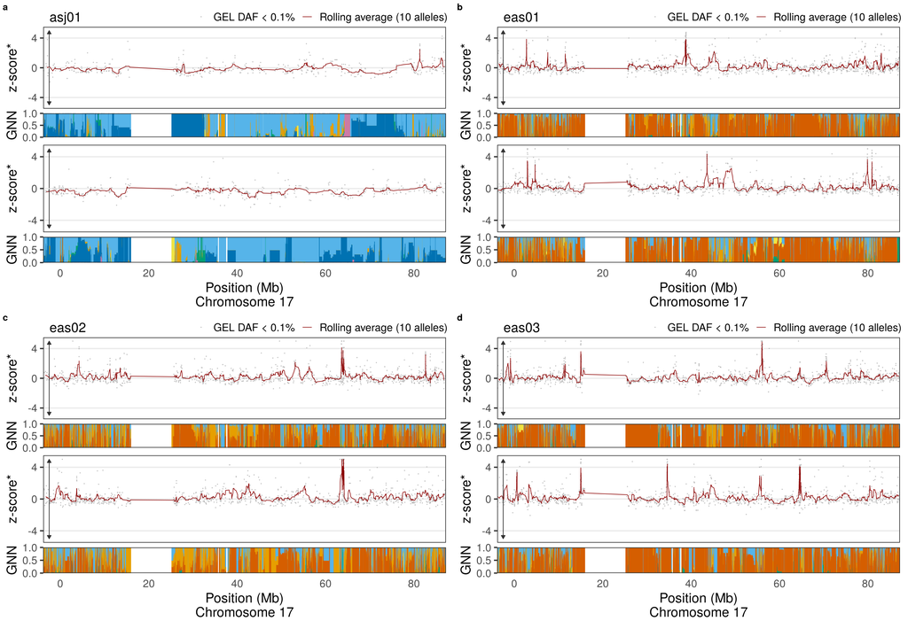

```r
pages[[1]]
```

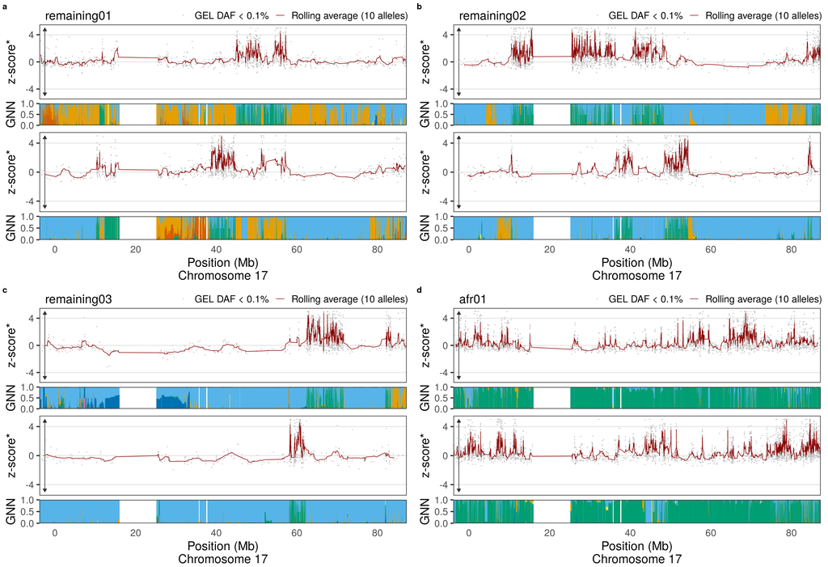

```r
pages[[2]]
```

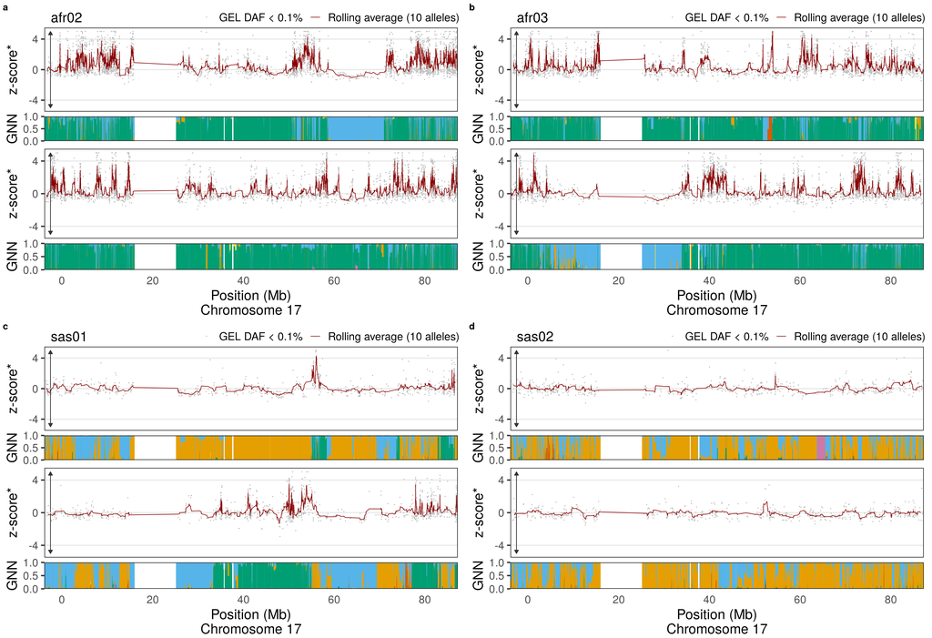

```r
pages[[3]]
```

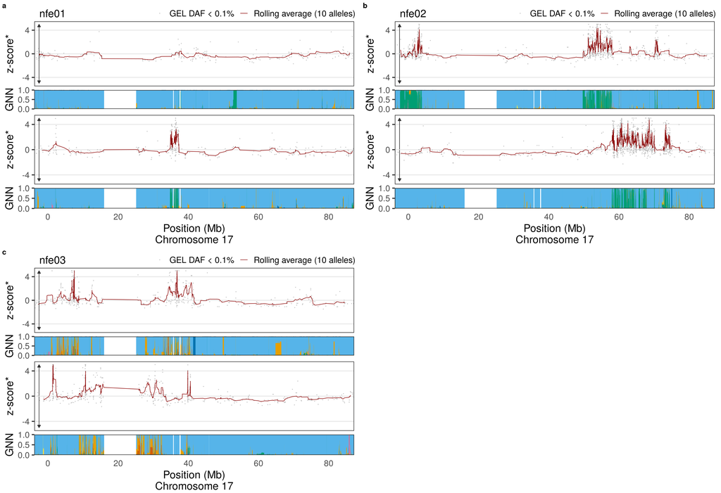

```r
pages[[4]]
```

Looks like the high Z scores, indicating older ages than expected given frequency, track regions of differentiated ancestries. Particularly African ancestries - however, even notable variation within “African ancestries”

## 4.7 AF information from external datasets

Lets see if AF information from external datasets can add more context.

```r
## Column names
column_names <- names(read_tsv(file.path(paste0(paths$output_dir, "all-chr17-df.tsv.gz")), n_max = 1))
selected_columns <- column_names[
  grepl("position|gnomad_genomes|ga100k_genomes", column_names)
]

pop_acs <- read_tsv(
  paste0(paths$output_dir, "all-chr17-df.tsv.gz"),
  col_select = all_of(selected_columns)
)
```

Subset - We’ll use nfe03 as an indicative example

```r
plot_4e <- comb_hap_plot_list[["nfe03"]]
```

```r
example_z_haps <- example_z_haps_all %>%
  filter(pseudo_id == "nfe03")
pops_acs_ext <- pop_acs |>
  filter(position %in% example_z_haps$position)
```

Plotting functions for external AF heatmaps

```r
plot_4f <- generate_af_heatmap_plots(
  adac_haps = example_z_haps,
  pop_acs_ext = pops_acs_ext,
  ts_df = ts_lf_merge %>%
    filter(chromosome == "chr17") %>%
    as_tibble(),
  AC_thresh = ur_ac_count,
  thresholds = c(4, 3, 2, 1, 0, -1),
  haplotypes_vec = c("Haplotype 1", "Haplotype 2"),
  datasets_vec = c("gnomad", "ga100k"),
  AF_col = "AF_log", label = "DAF",
  datasets_full_names_vec = c("gnomADv4.1", "GA100k")
)
```

Combine with the GNN/Z plot

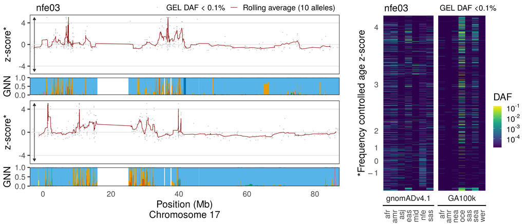

```r
bottom <- ggarrange(
  NULL,
  ggarrange(plot_4e, NULL, ncol = 1, heights = c(1, 0.06)),
  NULL,
  ggarrange(
    plot_grid(
    NULL,
    ggdraw() +
      draw_label(
        "nfe03",
        x = 0.1,
        y = 0.5,
        hjust = 0,
        size = 20
      ),
    NULL,
    ggdraw() +
      draw_label(
        "GEL DAF <0.1%",
        x = 0.1,
        y = 0.5,
        hjust = 0,
        size = 16
      ),
    nrow = 1,
    rel_widths = c(0.13, 0.1, 0.15, 0.5), # Adjust as needed for spacing
    align = "hv"
  ),
  plot_4f, ncol = 1, heights = c(0.075, 1)),
  nrow = 1,
  widths = c(0.01, 1, 0.05, 0.5)
)
bottom
```

Highlight the relevant individual on the singleton vs singleton age plot…

```r
ss_id <- top3_by_pop %>%
  filter(pseudo_id == "nfe03") %>%
  pull(singleton_sample_id)
plot4_d <- create_joint_density_plot(
  to_plot = anc_agesd_plot_data,
  highlight_id = ss_id,
  sample_name  = "nfe03",
  group_numbers = group_numbers,
  smooth_linewidth = 0.5,
  include_group_hists = FALSE,
  cor_size = 5.5,
  cor_method = "pearson",
  cor_label_x = 125,
  cor_label_y = 200,
  pop_colours_vec = pop_colours_vec
)
```

Arrange top… - Main figure 4 for paper…

```r
top <- ggarrange(
  plot_4_legend,
  NULL,
  ggarrange(
    ggarrange(
      plot_4a,
      NULL,
      ggarrange(
        plot_4b,
        plot_4c,
        ncol = 1,
        align = 'v',
        heights = c(0.5, 1)
      ),
      nrow = 1,
      widths = c(0.315, 0.05, 1)
    ),
    NULL,
    ggarrange(plot4_d, NULL, ncol = 1, heights = c(1, 0.015)),
    nrow = 1,
    widths = c(1.15, 0.05, 1, 0.01)
  ),
  ncol = 1,
  heights = c(0.1, 0.05, 1)
)
```

Arrange complete Figure

```r
fig4_plot <- ggarrange(
  ggarrange(top, NULL, widths = c(1, 0.075)),
  NULL,
  bottom,
  ncol = 1,
  heights = c(1, 0.04, 0.8)
)
```

Make PDF

```r
ggsave(paste0(paths$plots_dir, "tmp_main_figure_ancestry_to_edit.pdf"), width = 15.25, height = 13, device = cairo_pdf)
```

## 4.8 Oceania regression

Variants in the example individual nfe03 seem to have relationship between frequency controlled age-zscore and frequency in Oceania. - Are Common OCE mutations enriched among age-frequency Z score outliers (Z > 4) across the whole dataset?

```r
oce_logistic_test_z <-
outlier_logistic_loop_wrapper(
  df = ts_lf_merge %>%
    dplyr::select(AC_oce_ga100k_genomes, AN_oce_ga100k_genomes, time_z, chromosome, position, AC_ts) %>%
    as_tibble() %>%
    mutate(
      common_oce = ifelse(
        (AC_oce_ga100k_genomes / AN_oce_ga100k_genomes) > 0.01,
        "yes", "no"
      ),
      common_oce = ifelse(is.na(common_oce), "no", common_oce)
    ),
  outcome_col = "common_oce",
  outcome_vec = c("yes"),
  outlier_thresh_vec = c(4, Inf),
  outlier_col = "time_z",
  group_vals = c(1:ur_ac_count),
  direction = "between",
  correct_groups = FALSE,
  group_as_factor = FALSE
)
```

```
## Outlier column: time_z
```

Tabulate the regression statistics

```r
## exponetiate to get non log values
ocea_test_out <- oce_logistic_test_z %>%
  mutate(
    enrich    = exp(estimate),
    conf_high = exp(conf.high),
    conf_low  = exp(conf.low)
  ) %>%
  dplyr::select(
    c(enrich, conf_high, conf_low, std.error, p.value)
  )
knitr::kable(ocea_test_out, bookends = FALSE)
```

| enrich | conf_high | conf_low | std.error | p.value |
| --- | --- | --- | --- | --- |
| 12.79371 | 13.18014 | 12.41862 | 0.0151826 | 0 |